# Day 2: Making Inferences

Always start your R session by setting up the necessary libraries:

```r
# Load packages
library(tidyverse)
library(palmerpenguins)
```

## 1. From Sample to Population: What should we expect?

When we conduct an experiment, we may have some expectations about the result (theoretical probability) and then there is what we get (empirical probability):

```r
# Toss a coin once
sample(c("Heads", "Tails"), size = 1)
```

```
## [1] "Tails"
```

What if we toss it twice?

```r
# Toss a coin twice
sample(c("Heads", "Tails"), size = 2, replace = TRUE)
```

```
## [1] "Heads" "Tails"
```

### a. Law of Large Numbers

Let’s simulate coin flips to show how the proportion of getting heads stabilize over time:

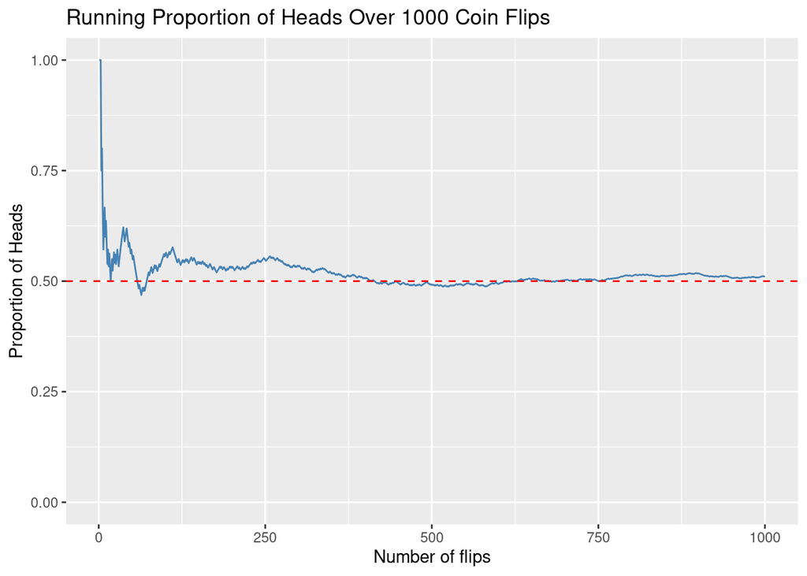

```r
# Simulate 1000 coin flips
coin_flips <- sample(c("Heads", "Tails"), size = 1000, replace = TRUE)

# Calculate the cumulative proportion of Heads
running_props <- cumsum(coin_flips == "Heads") / seq_along(coin_flips)

# Create a data frame for plotting
df_flips <- data.frame(
  flip_number = 1:1000,
  prop_heads = running_props)

# Represent the proportion of Heads as the number of flips increase
ggplot(df_flips, aes(x = flip_number, y = prop_heads)) +
  geom_line(color = "steelblue") +
  geom_hline(yintercept = 0.5, color = "red", linetype = "dashed") +
  ylim(0,1) +
  labs(title = "Running Proportion of Heads Over 1000 Coin Flips",
    x = "Number of flips",
    y = "Proportion of Heads")
```

### b. Binomial Distribution

The binomial distribution models the number of successes in a fixed number of independent trials. Here’s what it looks like for tossing a coin 100 times:

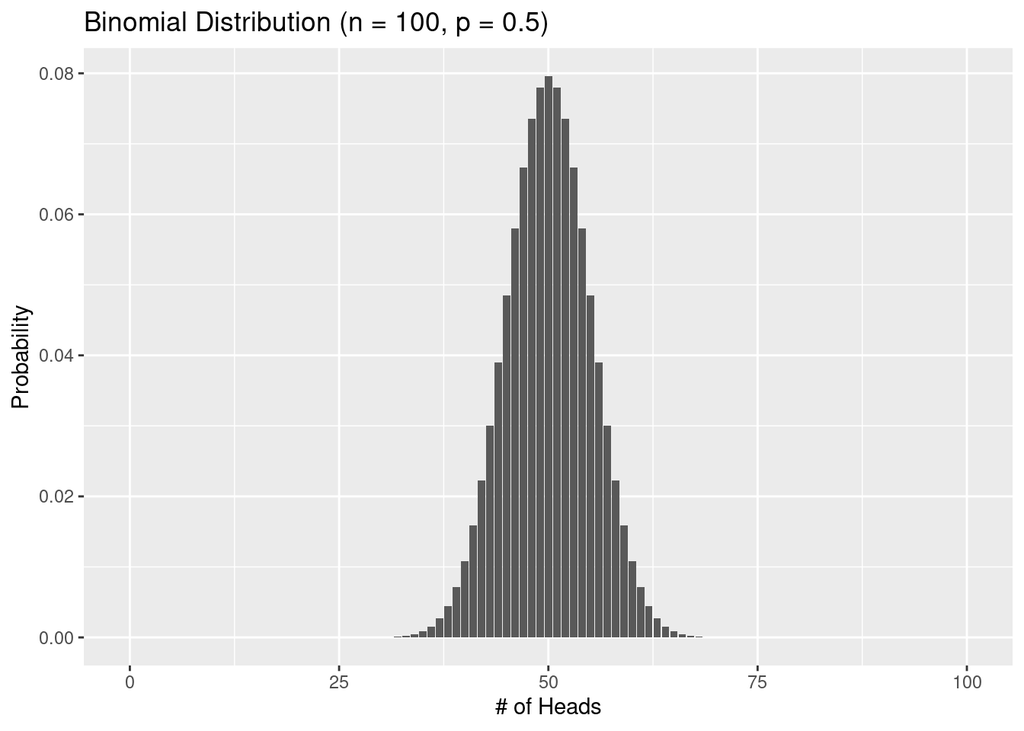

```r
ggplot(data.frame(x = 0:100), aes(x)) +
  stat_function(fun = dbinom, args = list(size = 100, prob = 0.5),
                geom = "bar", n = 101) +
  labs(title = "Binomial Distribution (n = 100, p = 0.5)",
       x = "# of Heads",
       y = "Probability")
```

If we increase the number of trials (n), the binomial distribution looks more and more like a normal distribution:

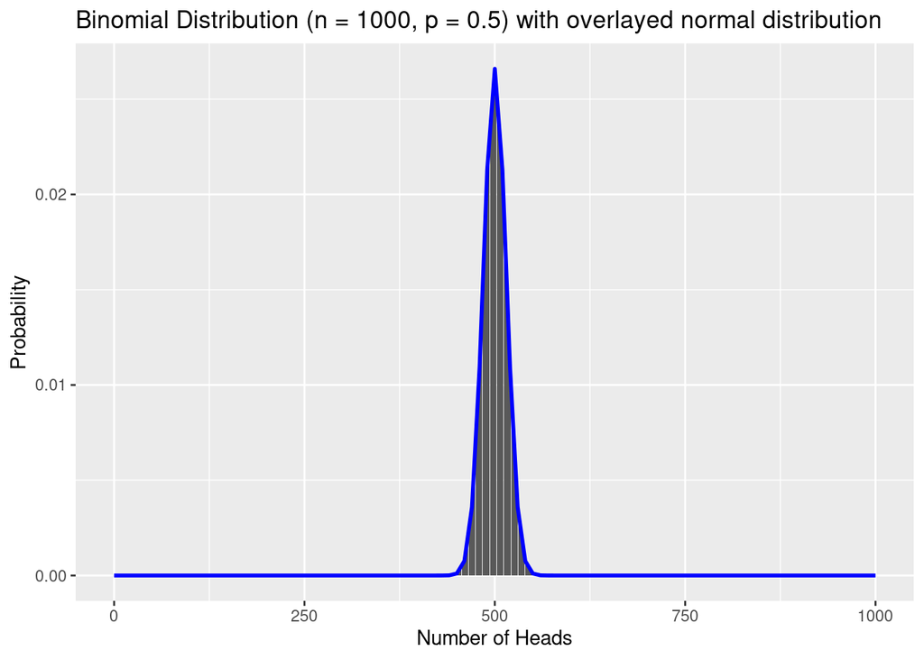

```r
ggplot(data.frame(x = 0:1000), aes(x)) +
  # Binomial distribution
  stat_function(fun = dbinom, args = list(size = 1000, prob = 0.5),
                geom = "bar", n = 1001) +
  # Corresponding normal distribution
  stat_function(fun = dnorm, args = list(mean = 500, sd = 15),
                geom = "line", linewidth = 1, color = "blue") +
  labs(title = "Binomial Distribution (n = 1000, p = 0.5) with overlayed normal distribution",
       x = "Number of Heads",
       y = "Probability")
```

### c. Normal Distribution

A normal distribution, also known as the Gaussian distribution, is a probability distribution for a continuous variable (infinitely many events) that is symmetric around the mean, depicting that data near the mean are more frequent than data far from the mean. It describes many natural phenomena.

Here is the standard normal distribution (with mean 0 and standard deviation 1):

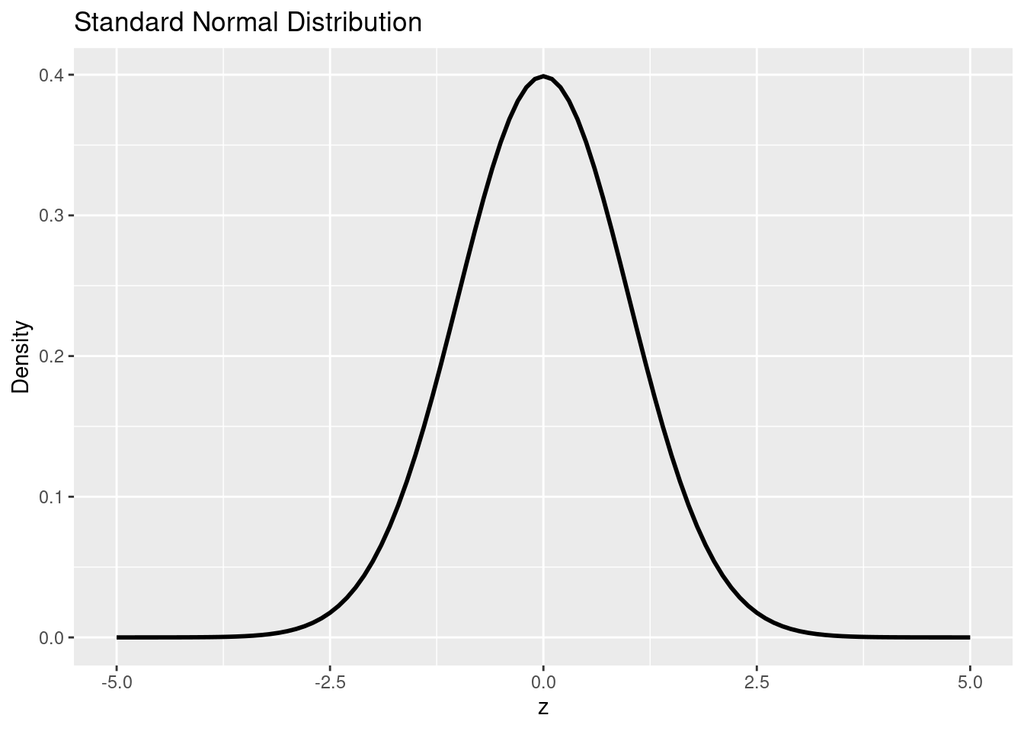

```r
ggplot(data.frame(z = c(-5, 5)), aes(z)) +
  stat_function(fun = dnorm, args = list(mean = 0, sd = 1),
                geom = "line", linewidth = 1) +
  labs(title = "Standard Normal Distribution",
       x = "z", y = "Density")
```

#### **Try it! Input different values for `mean` and `sd`. How does changing these values affect the curve?**

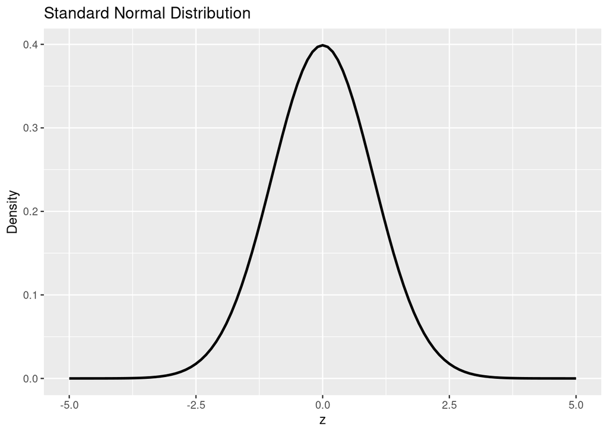

```r
# Type any code here
ggplot(data.frame(z = c(-5, 5)), aes(z)) +
  stat_function(fun = dnorm, args = list(mean = 0, sd = 1),
                geom = "line", linewidth = 1) +
  labs(title = "Standard Normal Distribution",
       x = "z", y = "Density")
```

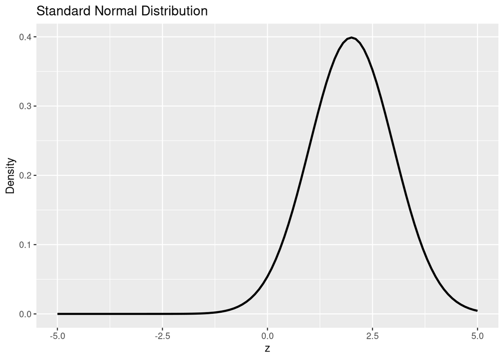

```r
ggplot(data.frame(z = c(-5, 5)), aes(z)) +
  stat_function(fun = dnorm, args = list(mean = 2, sd = 1),
                geom = "line", linewidth = 1) +
  labs(title = "Standard Normal Distribution",
       x = "z", y = "Density")
```

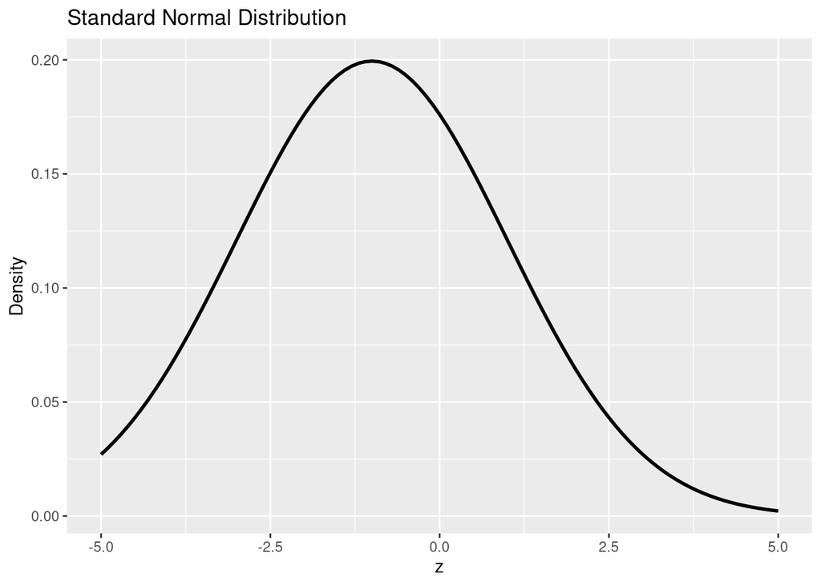

```r
ggplot(data.frame(z = c(-5, 5)), aes(z)) +
  stat_function(fun = dnorm, args = list(mean = -1, sd = 2),
                geom = "line", linewidth = 1) +
  labs(title = "Standard Normal Distribution",
       x = "z", y = "Density")
```

We can only find probabilities for a range of values for the normal distribution (probability of getting exactly one value among infinitely many is 0):

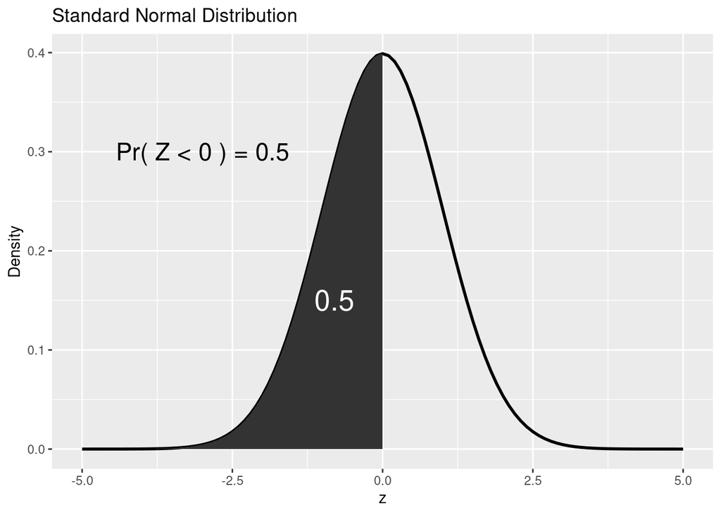

```r
ggplot(data.frame(z = c(-5, 5)), aes(z)) +
  stat_function(fun = dnorm, args = list(mean = 0, sd = 1),
                geom = "line", linewidth = 1) +
  # represent an area under the curve
  stat_function(fun = dnorm, geom = "area", xlim = c(-5,0)) +
  # place a text annotation on the grid
  annotate("text", x = -3, y = .3, label = "Pr( Z < 0 ) = 0.5", size = 6) +
  # place an text annotation on the shaded area
  annotate("text", x = -.8, y = .15, label = "0.5", size = 7, color = "white") +
  labs(title = "Standard Normal Distribution",
       x = "z", y = "Density")
```

We can calculate the probability of specific areas under the curve:

```r
# Calculate the cumulative distribution up until the value -2.5 for the standard normal distribution
pnorm(q = -2.5, mean = 0, sd = 1)
```

```
## [1] 0.006209665
```

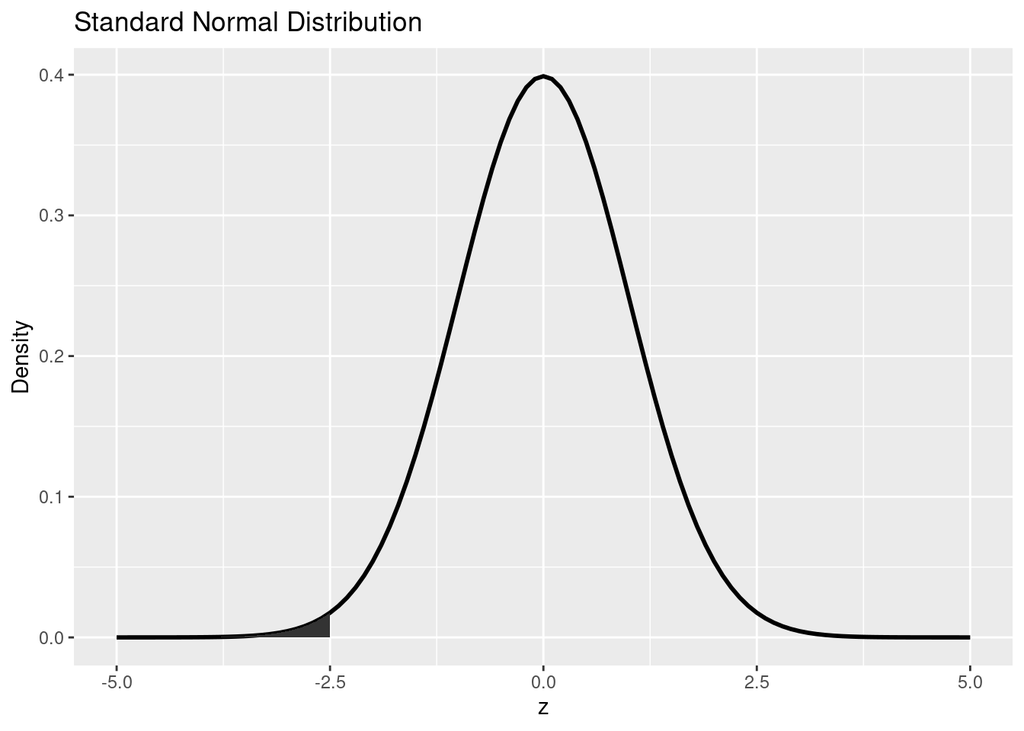

```r
# Corresponding graph
ggplot(data.frame(z = c(-5, 5)), aes(z)) +
  stat_function(fun = dnorm, args = list(mean = 0, sd = 1),
                geom = "line", linewidth = 1) +
  # represent an area under the curve
  stat_function(fun = dnorm, geom = "area", xlim = c(-5,-2.5)) +
  labs(title = "Standard Normal Distribution",
       x = "z", y = "Density")
```

Under the standard normal distribution, there is only a probability of about 0.006 to get a value 2.5 below the mean, or less.

Any normal distribution (any mean, any standard deviation) can be referred back to the standard normal distribution by calculating z-scores:

$$z = \frac{X-\mu}{\sigma}$$

### d. Sampling

In statistics, we sample individuals from a population. Assume a population of fish has a mean length of 106 mm and standard deviation of 30 mm. Consider sampling one fish from this population:

```r
# Sample 1 individual
rnorm(n = 1, mean = 106, sd = 30)
```

```
## [1] 109.1343
```

Did we all sample the same fish? Why/Why not?

#### **Try it! Assume we all sampled a fish with length 136 mm. Calculate the z-score for this fish. What was the probability to observe a fish of that length or higher?**

```r
# Type any code here
(136-106)/30
```

```
## [1] 1
```

```r
# These are all equivalent
1-pnorm(q = 136, mean = 106, sd = 30)
```

```
## [1] 0.1586553
```

```r
pnorm(q = 136, mean = 106, sd = 30, lower.tail = FALSE)
```

```
## [1] 0.1586553
```

```r
pnorm(q = (136-106)/30, mean = 0, sd = 1, lower.tail = FALSE)
```

```
## [1] 0.1586553
```

Now, let’s sample more than one fish, with 100 fish in our sample:

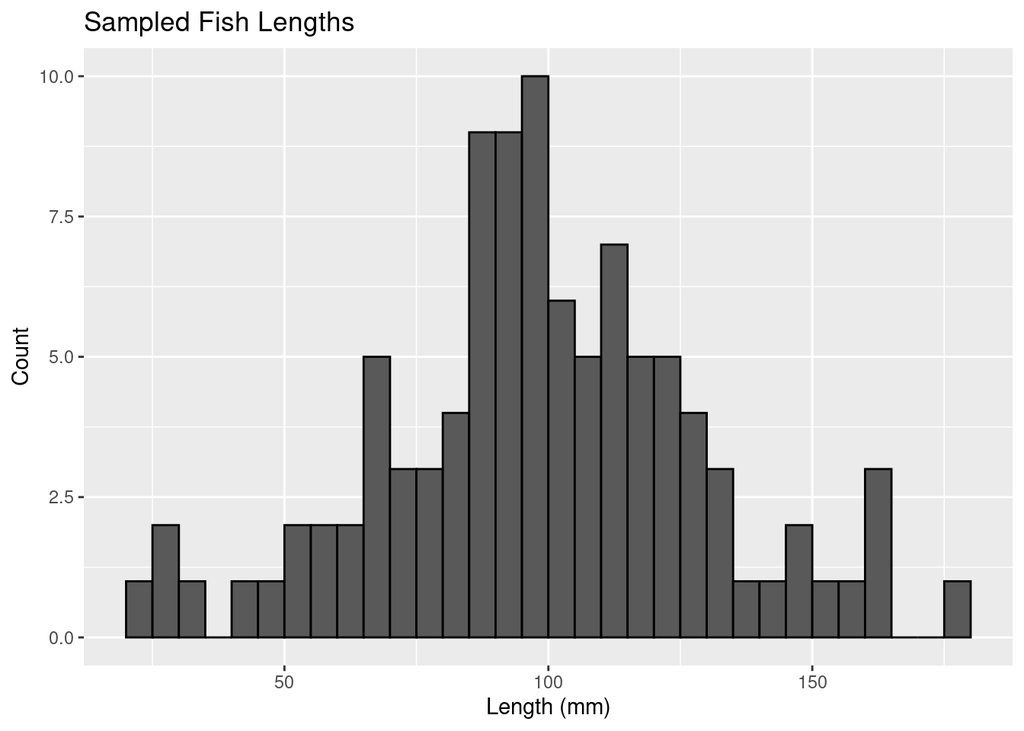

```r
# Sample 100 individuals
sample_fish <- rnorm(100, mean = 106, sd = 30)

# Represent the distribution
ggplot(data.frame(length = sample_fish), aes(x = length)) +
  geom_histogram(binwidth = 5, center = 2.5, color = "black") +
  labs(title = "Sampled Fish Lengths", x = "Length (mm)", y = "Count")
```

Did we all sample the same fish? Why/Why not?

Refer to [this applet](https://www.zoology.ubc.ca/~whitlock/Kingfisher/SamplingNormal.htm) for sampling from a normal distribution.

### e. Foundation of Inference: Central Limit Theorem

The Law of Large Numbers tells us that as sample size increases, the empirical proportion (sample statistic) approaches the theoretical probability (population parameter).

The Central Limit Theorem (CLT) helps us understand the distribution of a sample statistic (like the mean). It tells us that if we repeatedly take random samples of size n and calculate the mean, the distribution of those means will be approximately normal, even if the original data is skewed.

Refer to [this applet](https://www.zoology.ubc.ca/~whitlock/Kingfisher/CLT.htm) for demonstrating the Central Limit Theorem with many different types of distributions.

#### **Try it! Assume a population of fish has a mean length of 106 mm and standard deviation of 30 mm. Among a sample of 100 fish, you found a mean fish length of 136 mm. What was the probability to observe this mean of 136 mm or higher?**

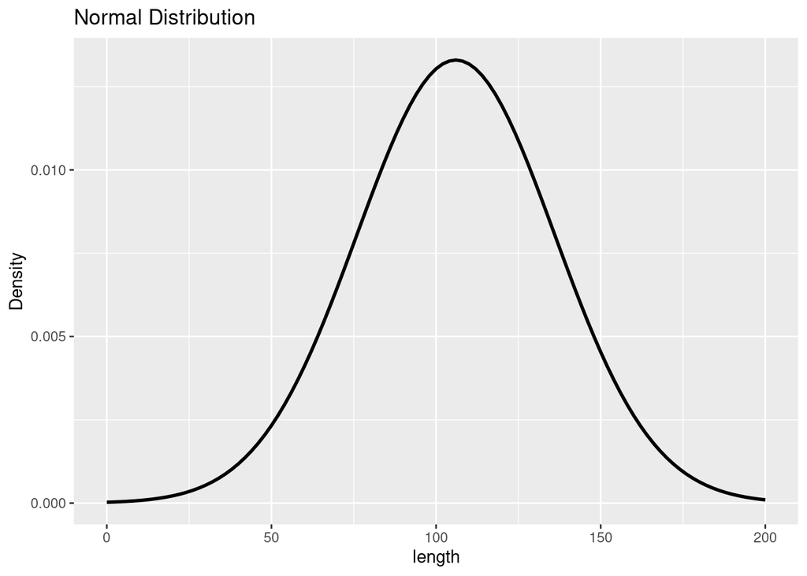

```r
# Population distribution
ggplot(data.frame(z = c(0, 200)), aes(z)) +
  stat_function(fun = dnorm, args = list(mean = 106, sd = 30),
                geom = "line", linewidth = 1) +
  labs(title = "Normal Distribution",
       x = "length", y = "Density")
```

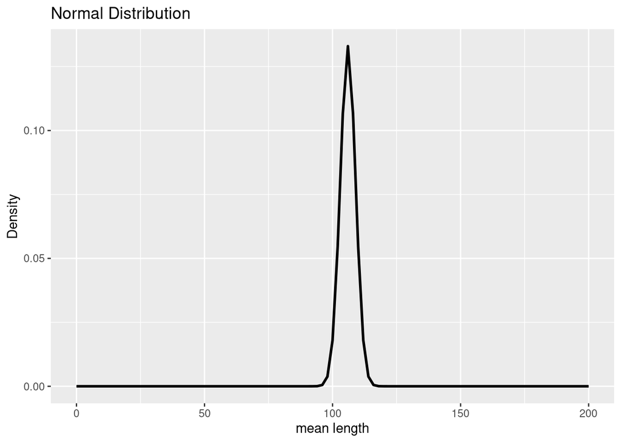

```r
# Sampling distribution
ggplot(data.frame(z = c(0, 200)), aes(z)) +
  stat_function(fun = dnorm, args = list(mean = 106, sd = 30/sqrt(100)),
                geom = "line", linewidth = 1) +
  labs(title = "Normal Distribution",
       x = "mean length", y = "Density")
```

```r
# Probability of getting a sample mean higher than 136
1-pnorm(q = 136, mean = 106, sd = 30/sqrt(100))
```

```
## [1] 0
```

## 2. Common Parametric Tests

Parametric tests assume a theoretical null distribution.

Let’s go back to the penguins dataset to conduct some common parametric tests in context:

```r
# Save a copy of the dataset in your environment as a dataframe
my_penguins <- as.data.frame(penguins)
```

### Student’s t-distribution

This distribution is similar to the normal distribution but needs one more parameter: degrees of freedom.

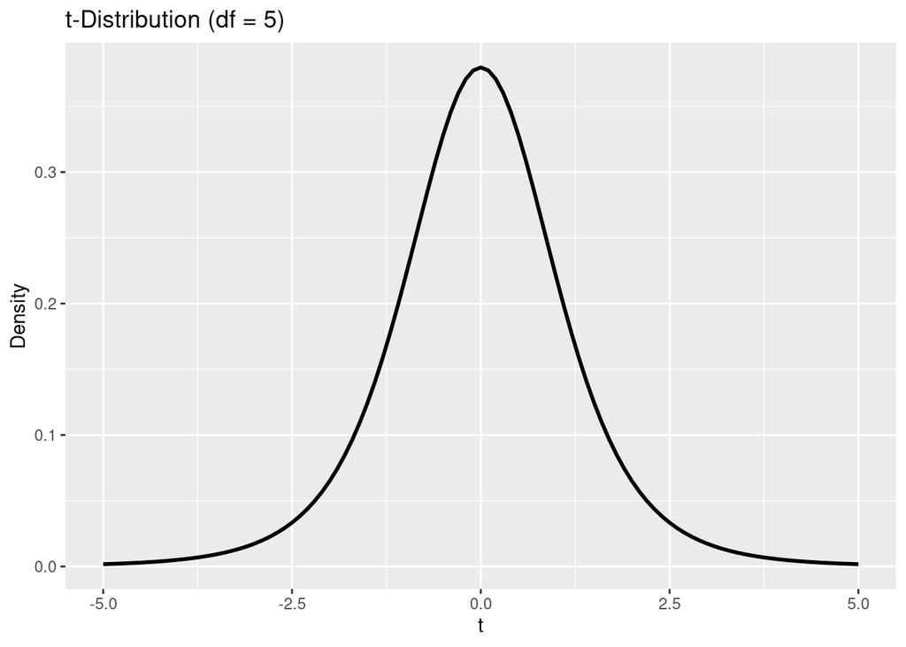

```r
# Represent the t-distribution with degree of freedom 5
ggplot(data.frame(t = c(-5, 5)), aes(t)) +
  stat_function(fun = dt, args = list(df = 5),
                geom = "line", linewidth = 1) +
  labs(title = "t-Distribution (df = 5)",
       x = "t", y = "Density")
```

The larger the degrees of freedom are, the closer the distribution gets to a normal distribution:

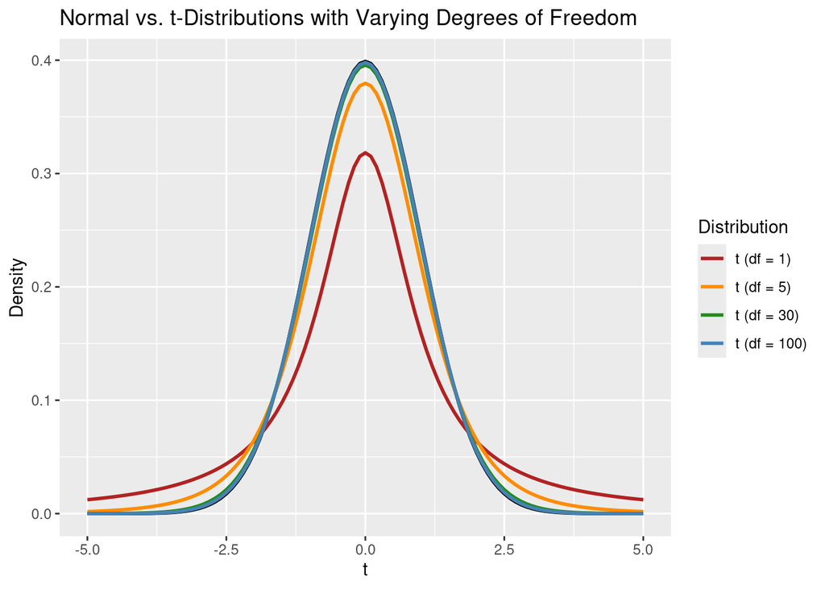

```r
ggplot(data.frame(t = c(-5, 5)), aes(x = t)) +
  # Standard normal
  stat_function(fun = dnorm, args = list(mean = 0, sd = 1),
                geom = "line", linewidth = 1) +
  # t-distributions
  stat_function(fun = dt, args = list(df = 1), aes(color = "t (df = 1)"), linewidth = 1) +
  stat_function(fun = dt, args = list(df = 5), aes(color = "t (df = 5)"), linewidth = 1) +
  stat_function(fun = dt, args = list(df = 30), aes(color = "t (df = 30)"), linewidth = 1) +
  stat_function(fun = dt, args = list(df = 100), aes(color = "t (df = 100)"), linewidth = 1) +
  labs(title = "Normal vs. t-Distributions with Varying Degrees of Freedom",
       x = "t", y = "Density", color = "Distribution") +
  scale_color_manual(
    name = "Distribution",
    values = c(
      "t (df = 1)" = "firebrick",
      "t (df = 5)" = "darkorange",
      "t (df = 30)" = "forestgreen",
      "t (df = 100)" = "steelblue",
      "Normal" = "black"
    ),
    breaks = c("t (df = 1)", "t (df = 5)", "t (df = 30)", "t (df = 100)", "Normal"))
```

### a. One-sample t-test

From previous research, we learn that Gentoo penguins are about 12 lbs on average, which is about 5440 grams.

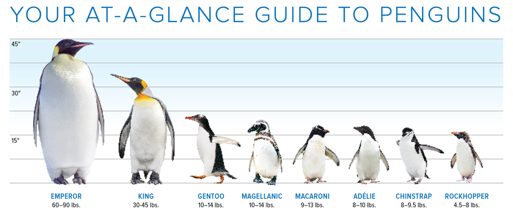

Focusing on this species, answer the research question below:

```r
# Save a copy of the dataset in your environment as a dataframe
my_gentoo <- my_penguins |>
  filter(species == "Gentoo")
```

> Research Question: Is the mean body mass of Gentoo penguins different from 5440 grams?
1. Hypotheses:
- H0: The mean body mass of Gentoo penguins is 5440 grams.
- Ha: The mean body mass of Gentoo penguins is not 5440 grams.
2. Find descriptive statistics:

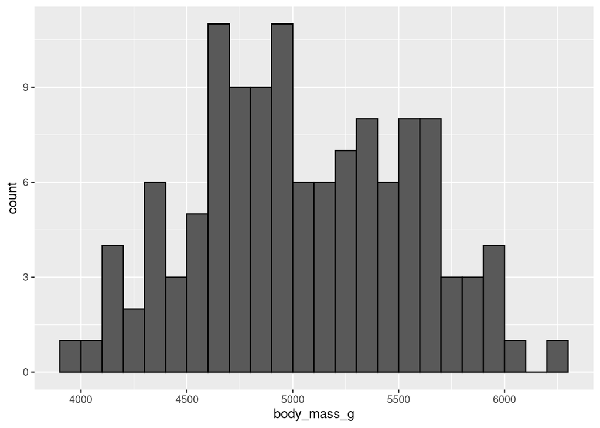

```r
my_gentoo |>
  # Make a plot
  ggplot() +
  # Use geom_histogram and define mapping aesthetics
  geom_histogram(aes(x = body_mass_g),
                 # Set bin width and center
                 binwidth = 100, center = 50, color = "black")
```

```r
# Report mean and sd
my_gentoo |>
  # Summary statistics
  summarize(
    mean = mean(body_mass_g, na.rm = TRUE),
    median = median(body_mass_g, na.rm = TRUE),
    sd = sd(body_mass_g, na.rm = TRUE),
    IQR = IQR(body_mass_g, na.rm = TRUE),
    min_mass = min(body_mass_g, na.rm = TRUE),
    max_mass = max(body_mass_g, na.rm = TRUE))
```

```
##       mean median       sd IQR min_mass max_mass
## 1 5076.016   5000 504.1162 800     3950     6300
```

3. Compare the estimate to the claim:

```r
# Conduct the test
t.test(my_gentoo$body_mass_g, mu = 5440)
```

```
##
##  One Sample t-test
##
## data:  my_gentoo$body_mass_g
## t = -8.0076, df = 122, p-value = 7.818e-13
## alternative hypothesis: true mean is not equal to 5440
## 95 percent confidence interval:
##  4986.034 5165.998
## sample estimates:
## mean of x
##  5076.016
```

4. Interpret in context: The population mean body mass of the Gentoo penguins is significantly different from 5440 grams (t = -8, df = 122, p < 0.001).

Note that R provides the 95% confidence interval in the output. Write a sentence to interpret it: We are 95% confident that the true mean body mass of Gentoo penguins is between 4986 and 5166 grams.

What do you think about the assumptions?

- Random sample: check context
- Independent observations: check context (would not be met if some penguins were siblings for example)
- Normality: distribution of body mass is approximately normally distributed

### b. Independent t-test

> Research Question: Is there a difference in body mass between male and female penguins?
1. Hypotheses:
- H0: The mean body mass of male penguins equals that of female penguins.
- Ha: The mean body mass of male penguins differs from that of female penguins.
2. Find descriptive statistics:

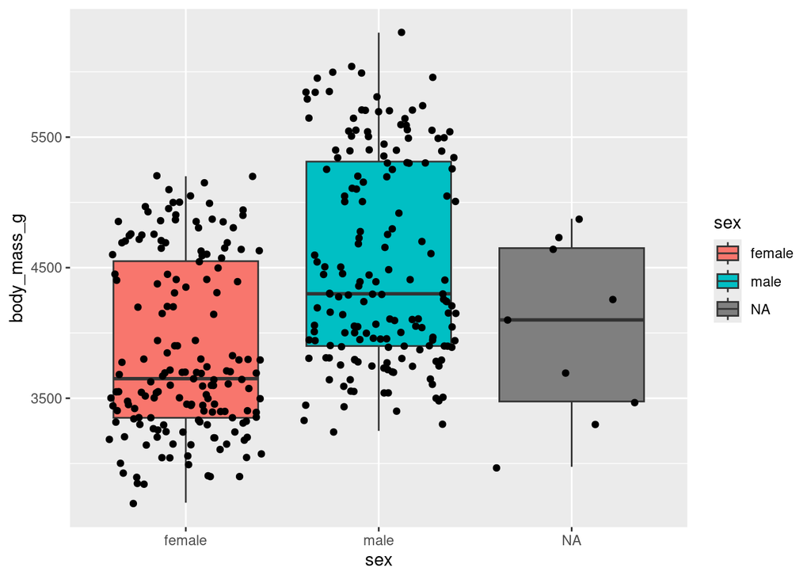

```r
my_penguins |>
  # Make a plot
  ggplot() +
  # Use geom_boxplot and define mapping aesthetics: x = predictor, y = outcome
  geom_boxplot(aes(y = body_mass_g, x = sex, fill = sex)) +
  # Add the data
  geom_jitter(aes(y = body_mass_g, x = sex))
```

```r
# Report mean and sd
my_penguins |>
  # Split the data in groups
  group_by(sex) |>
  # Summary statistics
  summarize(
    mean = mean(body_mass_g, na.rm = TRUE),
    median = median(body_mass_g, na.rm = TRUE),
    sd = sd(body_mass_g, na.rm = TRUE),
    IQR = IQR(body_mass_g, na.rm = TRUE),
    min_mass = min(body_mass_g, na.rm = TRUE),
    max_mass = max(body_mass_g, na.rm = TRUE))
```

```
## # A tibble: 3 × 7
##   sex     mean median    sd   IQR min_mass max_mass
##   <fct>  <dbl>  <dbl> <dbl> <dbl>    <int>    <int>
## 1 female 3862.   3650  666. 1200      2700     5200
## 2 male   4546.   4300  788. 1412.     3250     6300
## 3 <NA>   4006.   4100  679. 1175      2975     4875
```

3. Compare the estimate to the claim:

```r
# Conduct the test
t.test(body_mass_g ~ sex, data = my_penguins, var.equal = TRUE)
```

```
##
##  Two Sample t-test
##
## data:  body_mass_g by sex
## t = -8.5417, df = 331, p-value = 4.897e-16
## alternative hypothesis: true difference in means between group female and group male is not equal to 0
## 95 percent confidence interval:
##  -840.8014 -526.0222
## sample estimates:
## mean in group female   mean in group male
##             3862.273             4545.685
```

4. Interpret in context: There is a significant difference between the average body mass in female/male penguins (t = -8.54, df = 331, p < 0.001).

Note that R provides the 95% confidence interval in the output. Write a sentence to interpret it: We are 95% confident the mean body mass of male penguins is between 526 and 841 grams more than female.

What do you think about the assumptions?

- Random sample
- Independent observations
- Normality
- Equal variance

### F-Distribution

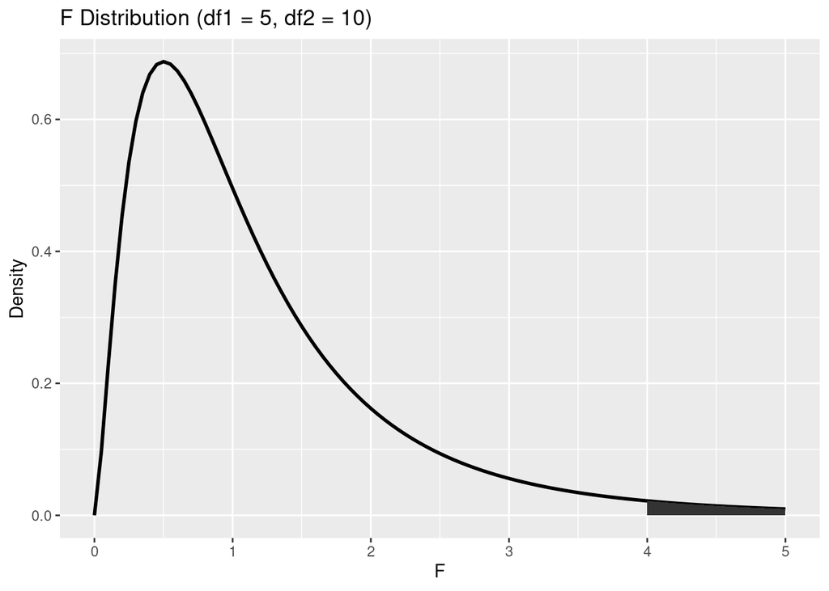

```r
# Represent the F-distribution with degree of freedom 5, 10
ggplot(data.frame(F = c(0, 5)), aes(x = F)) +
  stat_function(fun = df, args = list(df1 = 5, df2 = 10),
                geom = "line", linewidth = 1) +
  stat_function(fun = df, args = list(df1 = 5, df2 = 10),
                geom = "area", xlim = c(4,5)) +
  labs(title = "F Distribution (df1 = 5, df2 = 10)",
       x = "F", y = "Density")
```

```r
# Corresponding probability of getting F > 4
1- pf(q = 4, df1 = 5, df2 = 10)
```

```
## [1] 0.0296753
```

### c. ANOVA

> Research Question: Is there a difference in body mass between the three species of penguins?
1. Hypotheses:
- H0: The mean body mass is the same across species.
- Ha: At least of the mean body mass is different compared to other species.
2. Find descriptive statistics:

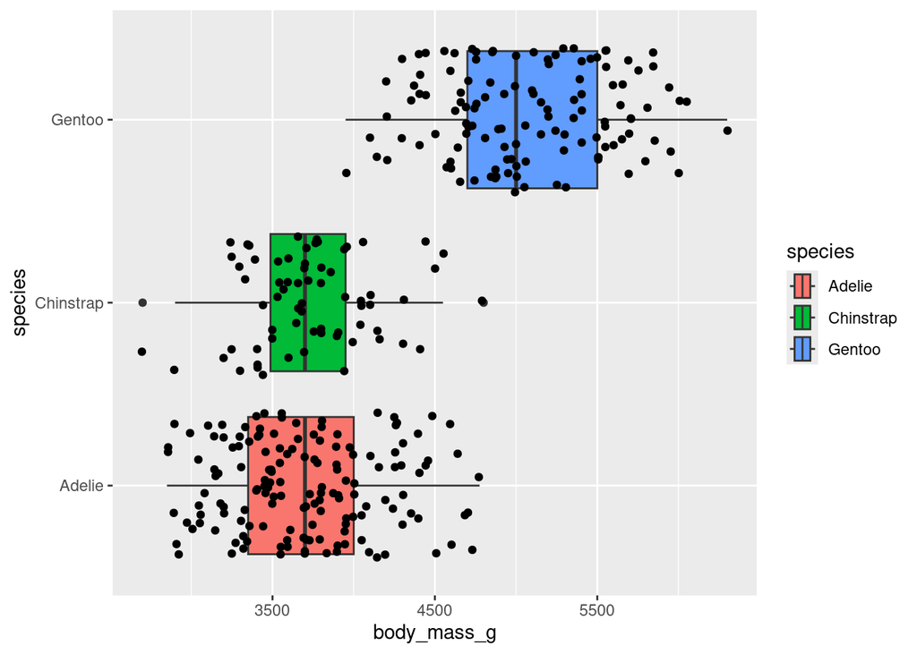

```r
my_penguins |>
  # Make a plot
  ggplot() +
  # Use geom_boxplot and define mapping aesthetics: x = predictor, y = outcome
  geom_boxplot(aes(x = body_mass_g, y = species, fill = species)) +
  # Add the data
  geom_jitter(aes(x = body_mass_g, y = species))
```

```r
# Report mean and sd
my_penguins |>
  group_by(species) |>
  summarize(mean = mean(body_mass_g, na.rm = TRUE),
            sd = sd(body_mass_g, na.rm = TRUE))
```

```
## # A tibble: 3 × 3
##   species    mean    sd
##   <fct>     <dbl> <dbl>
## 1 Adelie    3701.  459.
## 2 Chinstrap 3733.  384.
## 3 Gentoo    5076.  504.
```

3. Compare the estimate to the claim:

```r
# Conduct the test
anova_model <- aov(body_mass_g ~ species, data = my_penguins)
summary(anova_model)
```

```
##              Df    Sum Sq  Mean Sq F value Pr(>F)
## species       2 146864214 73432107   343.6 <2e-16 ***
## Residuals   339  72443483   213698
## ---
## Signif. codes:  0 '***' 0.001 '**' 0.01 '*' 0.05 '.' 0.1 ' ' 1
## 2 observations deleted due to missingness
```

4. Interpret in context: There is a significant difference in population mean body mass across the three species (F = 343.6, df = (2, 339), p < 0.001).

Note that R does not provide the $R^2$ value confidence interval in the output. However you can calculate it based on the output of the test:

```r
# Calculate R-squared
ss_total <- 146864214 + 72443483
ss_between <- 146864214
R_squared <- ss_between / ss_total
R_squared
```

```
## [1] 0.669672
```

Write a sentence to interpret it: About 67% of the variation in body mass can be explained by differences between species.

What do you think about the assumptions?

- Random sample
- Independent observations
- Normality
- Equal variance

#### Post-Hoc analysis

Are all the species different from one another?

```r
# Run post-hoc analysis for the previous model
TukeyHSD(anova_model)
```

```
##   Tukey multiple comparisons of means
##     95% family-wise confidence level
##
## Fit: aov(formula = body_mass_g ~ species, data = my_penguins)
##
## $species
##                        diff       lwr       upr     p adj
## Chinstrap-Adelie   32.42598 -126.5002  191.3522 0.8806666
## Gentoo-Adelie    1375.35401 1243.1786 1507.5294 0.0000000
## Gentoo-Chinstrap 1342.92802 1178.4810 1507.3750 0.0000000
```

There are statistical significant differences in body mass between Gentoo-Adelie and Gentoo-Chinstrap, but not between Chinstrap-Adelie.

### Chi-squared Distribution

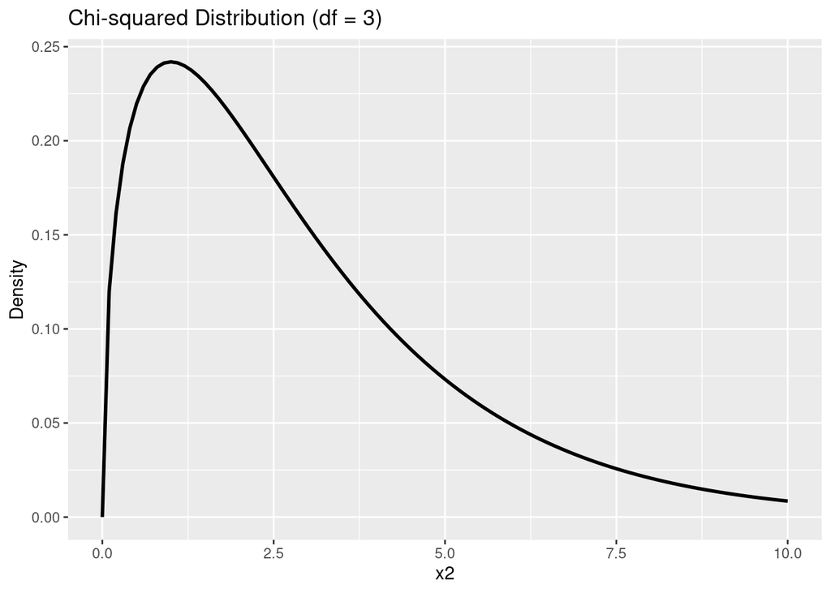

```r
# Represent the X2-distribution with degree of freedom 3
ggplot(data.frame(x2 = c(0, 10)), aes(x2)) +
  stat_function(fun = dchisq, args = list(df = 3),
                geom = "line", linewidth = 1) +
  labs(title = "Chi-squared Distribution (df = 3)",
       x = "x2", y = "Density")
```

### d. Chi-squared Goodness of Fit

> Research Question: Is there a different amount of penguins for each species?
1. Hypotheses:
- H0: All species are equally represented (1/3 each).
- Ha: The proportions of penguin species are not all equal.
2. Find descriptive statistics:

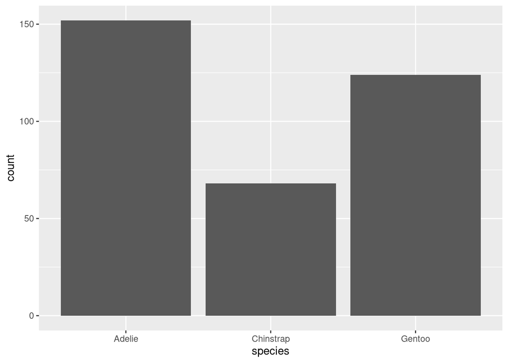

```r
my_penguins |>
  # Make a plot
  ggplot() +
  # Use geom_bar and define mapping aesthetics
  geom_bar(aes(x = species))
```

```r
# Report frequencies
table(my_penguins$species)
```

```
##
##    Adelie Chinstrap    Gentoo
##       152        68       124
```

3. Compare the estimate to the claim:

```r
# Conduct the test
chisq.test(table(my_penguins$species), p=c(1/3,1/3,1/3))
```

```
##
##  Chi-squared test for given probabilities
##
## data:  table(my_penguins$species)
## X-squared = 31.907, df = 2, p-value = 1.179e-07
```

4. Interpret in context: The proportions of penguin species are not all equal to 1/3 (X-squared = 31.9, df = 2, p-value < 0.001).

What do you think about the assumptions?

- Random sample
- Independent observations
- Sample size

### e. Chi-squared Test of Independence

> Research Question: Is there a difference in the sex distribution across species?
1. Hypotheses:
- H0: Species and sex are independent.
- Ha: Species and sex are not independent (dependent).
2. Find descriptive statistics:

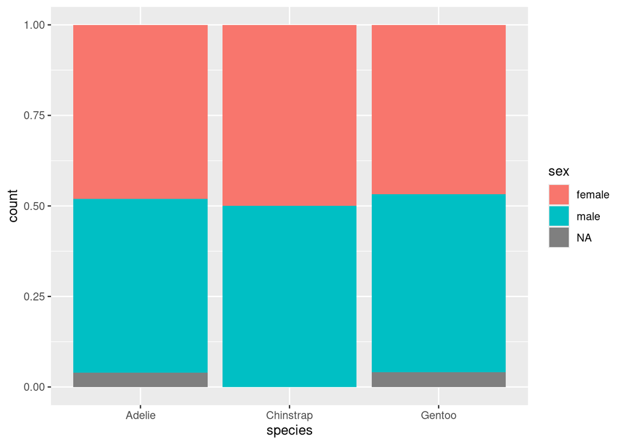

```r
my_penguins |>
  # Make a plot
  ggplot() +
  # Use geom_bar and define mapping aesthetics with fill
  geom_bar(aes(x = species, fill = sex), position = "fill")
```

```r
# Report frequencies and percentages
my_penguins |>
  # Report counts for each pair of groups
  count(species, sex) |>
  # Split by one group
  group_by(species) |>
  # Calculate proportions
  mutate(prop = n / sum(n)) |>
  # Reshape results
  select(-n) |>
  pivot_wider(names_from = sex, values_from = prop, values_fill = 0)
```

```
## # A tibble: 3 × 4
## # Groups:   species [3]
##   species   female  male   `NA`
##   <fct>      <dbl> <dbl>  <dbl>
## 1 Adelie     0.480 0.480 0.0395
## 2 Chinstrap  0.5   0.5   0
## 3 Gentoo     0.468 0.492 0.0403
```

3. Compare the estimate to the claim:

```r
# Conduct the test
chisq.test(table(my_penguins$species, my_penguins$sex))
```

```
##
##  Pearson's Chi-squared test
##
## data:  table(my_penguins$species, my_penguins$sex)
## X-squared = 0.048607, df = 2, p-value = 0.976
```

4. Interpret in context: The proportions of male/female penguins is not significant different across species (X-squared = 0.05, df = 2, p-value = 0.976).

What do you think about the assumptions?

- Random sample
- Independent observations
- Sample size

## 3. Failing Assumptions

We can further check some assumptions and consider alternatives if these assumptions are failing.

### a. Equal Variance assumption

Check for equal variance assumption with Levene’s test from the `car` package:

```r
# Call the car package
library(car)
# Check for equal variances
leveneTest(body_mass_g ~ sex, data = my_penguins)
```

```
## Levene's Test for Homogeneity of Variance (center = median)
##        Df F value  Pr(>F)
## group   1  6.0586 0.01435 *
##       331
## ---
## Signif. codes:  0 '***' 0.001 '**' 0.01 '*' 0.05 '.' 0.1 ' ' 1
```

There seems to be an issue with equal variance!

When comparing two independent groups, we can conduct a Welch’s t-test instead of the independent t-test:

```r
# Conduct a Welch's t-test (var.equal = FALSE)
t.test(body_mass_g ~ sex, data = my_penguins, var.equal = FALSE)
```

```
##
##  Welch Two Sample t-test
##
## data:  body_mass_g by sex
## t = -8.5545, df = 323.9, p-value = 4.794e-16
## alternative hypothesis: true difference in means between group female and group male is not equal to 0
## 95 percent confidence interval:
##  -840.5783 -526.2453
## sample estimates:
## mean in group female   mean in group male
##             3862.273             4545.685
```

The difference is still significant.

### b. Normality assumption

```r
# Check for normality
shapiro.test(my_penguins$body_mass_g)
```

```
##
##  Shapiro-Wilk normality test
##
## data:  my_penguins$body_mass_g
## W = 0.95921, p-value = 3.679e-08
```

There seems to be an issue with normality! However, this test is sensitive to large sample sizes and visual inspection is often more informative in practice:

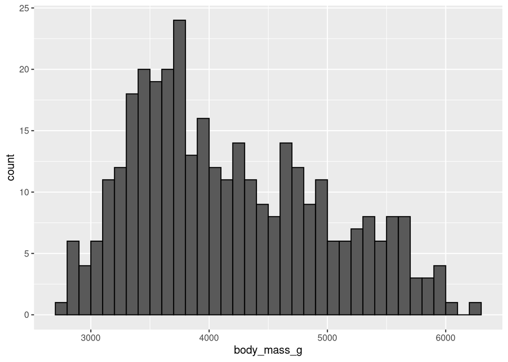

```r
# Check for normality visually
my_penguins |>
  # Make a plot
  ggplot() +
  # Use geom_histogram and define mapping aesthetics
  geom_histogram(aes(x = body_mass_g),
                 # Set bin width and center
                 binwidth = 100, center = 50, color = "black")
```

This distribution seems slightly skewed to the right. We can apply a log-transformation:

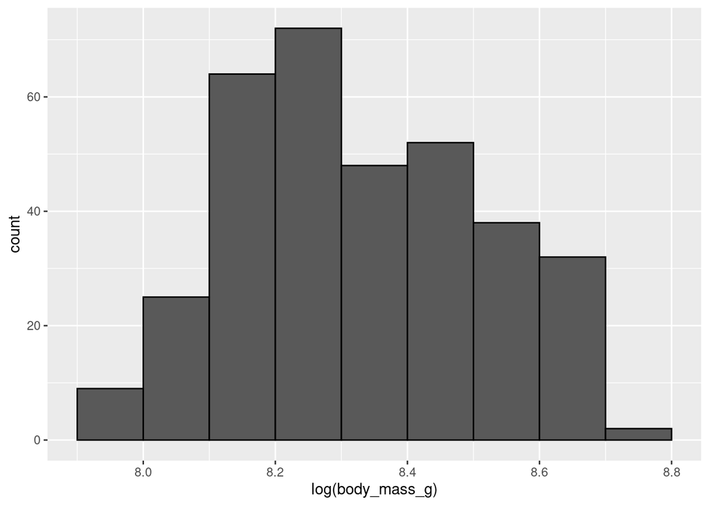

```r
# Check for normality visually for the transformed variable
my_penguins |>
  # Make a plot
  ggplot() +
  # Use geom_histogram and define mapping aesthetics
  geom_histogram(aes(x = log(body_mass_g)),
                 # Set bin width and center
                 binwidth = 0.1, center = 0.05, color = "black")
```

The distribution seems to be more symmetric after transformation.

### c. Considering Nonparametric Tests

In the previous worksheet, we introduced the idea of hypothesis testing with a randomization/permutation test. These tests can be applied when parametric tests fails.

Bootstrapping is also a nonparametric method that estimates sampling variability by resampling from the observed data with replacement. Let’s estimate the sampling distribution of the difference in mean body mass between male and female penguins:

```r
# Bootstrap 1000 resamples
bootstrap_diffs <- data.frame(
  diff = replicate(1000, {
    my_penguins |>
      # Filter missing values
      filter(!is.na(sex), !is.na(body_mass_g)) |>
      # For each group
      group_by(sex) |>
      # Resample within each group
      slice_sample(prop = 1, replace = TRUE) |>
      summarize(mean_mass = mean(body_mass_g)) |>
      summarize(diff = diff(mean_mass)) |>
      pull(diff)
  }))
```

Let’s visualize the bootstrap distribution:

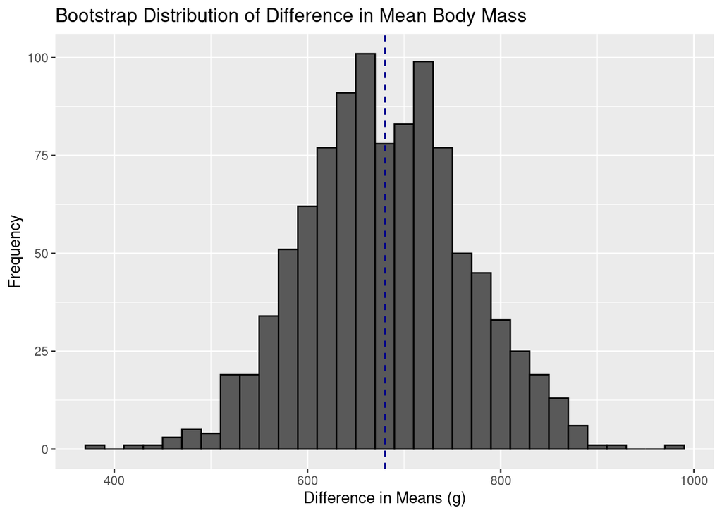

```r
ggplot(bootstrap_diffs, aes(x = diff)) +
  # Represent all possible differences
  geom_histogram(binwidth = 20, color = "black") +
  # Represent the mean differences
  geom_vline(aes(xintercept = mean(diff)), color = "darkblue", linetype = "dashed") +
  labs(title = "Bootstrap Distribution of Difference in Mean Body Mass",
    x = "Difference in Means (g)", y = "Frequency")
```

Each bootstrap sample estimates the difference in mean body mass between male and female penguins and the histogram shows how much this difference varies due to sampling. We can use this distribution to compute a confidence interval, for example using quantiles of the bootstrap distribution:

```r
quantile(bootstrap_diffs$diff, probs = c(0.025, 0.975))
```

```
##     2.5%    97.5%
## 523.1724 847.4040
```

There are also some other tests that do not assume a specific distribution such as the Mann-Whitney U Test (Wilcoxon):

```r
wilcox.test(body_mass_g ~ sex, data = my_penguins)
```

```
##
##  Wilcoxon rank sum test with continuity correction
##
## data:  body_mass_g by sex
## W = 6874.5, p-value = 1.813e-15
## alternative hypothesis: true location shift is not equal to 0
```

Note that the p-value is slightly higher than for the parametric test above: we say nonparametric are more conservative.

## Recommended Resources

1. [R for Data Science](https://r4ds.hadley.nz/)
2. [Introductory Statistics in R](https://tjfisher19.github.io/introStatModeling/introductory-statistics-in-r.html)
3. [Sampling from a Normal Distribution](https://www.zoology.ubc.ca/~whitlock/Kingfisher/SamplingNormal.htm)
4. [Demonstrating the Central Limit Theorem](https://www.zoology.ubc.ca/~whitlock/Kingfisher/CLT.htm)